# Okhotsk Diatom Beta Diversity Partition

Chih-Lin Wei

2026-10-28

```r
library(readxl)
library(dplyr)
library(plyr)
library(ggplot2)
library(ggpattern)
library(reshape2)
library(doBy)
library(knitr)
library(kableExtra)

large <- theme(legend.title = element_text(size=20),
        legend.text = element_text(size=20),
        axis.title = element_text(size=20),
        axis.text = element_text(size=20),
        strip.text = element_text(size=20))
vert_x <- theme(axis.text.x.bottom = element_text(angle = 45, hjust = 1, face="italic"))
no_strip.x <- theme(strip.background.x = element_blank(),
                  strip.text.x = element_blank())
no_strip.y <- theme(strip.background.y = element_blank(),
                  strip.text.y = element_blank())
no_legend <- theme(legend.position = "none")

load(file="../Rdata/mis.rda") # Marine Isotope Stage
load(file="../Rdata/spp.rda") # Raw species count
load(file="../Rdata/sam.rda") # Sample information
zero <- rowSums(spp)==0 # The sample with zero count

spp <- spp[!zero,]
sam <- sam[!zero,]
```

# 1 Partioning Sorensen dissimilarities into turnover and nestedness components

We separated the total Sorensen dissimilarities into species turnover and nestedness components using the algorithms developed by Baselga ([2010](https://doi.org/10.1111/j.1466-8238.2009.00490.x), [2012](https://doi.org/10.1111/j.1466-8238.2011.00756.x)). We fit distance decay models to pairwise assemblage dissimilarities, including their turnover and nestedness components, as well as the total dissimilarities. The exponential models were fitted using the Levenberg-Marquardt Nonlinear Least-Squares Algorithm ([Gómez-Rodríguez & Baselga, 2018](https://doi.org/10.1111/ecog.03693); [Martínez-Santalla et al., 2022](https://doi.org/10.1111/jbi.14351); [Martín-Devasa et al., 2022](https://doi.org/10.1111/ddi.13550)). The significance of the models was estimated through 999 permutations. The pairwise dissimilarities between pre-MPT and MPT samples, between MPT and post-MPT samples, and between pre-MPT and post-MPT samples, as well as among the Pre-MPT samples, MPT samples, and post-MPT samples were decomposed, respectively.

## 1.1 Pairwise dissimilarities between pre-MPT and MPT

```r
library(betapart)
library(vegan)

pos <- which(sam$Period2=="Post")

# Partioning Sorensen dissimilarities
be <- beta.pair(spp[-pos,] %>% decostand("pa"))

bd <- list()
bd$beta.sim$lab <- c("(a)", "Species turnover")
bd$beta.sim$dis <- be$beta.sim
bd$beta.sne$lab <- c("(b)", "Nestedness")
bd$beta.sne$dis <- be$beta.sne
bd$beta.sor$lab <- c("(c)", "Total dissimilarity")
bd$beta.sor$dis <- be$beta.sor

pre <- which(sam[-pos, "Period2"]=="Pre")
mpt <- which(sam[-pos, "Period2"]=="MPT")
```

```r
library(patchwork)

p1 <- lapply(bd, FUN=function(x){
  dis <- as.matrix(x$dis)
  dis[pre, pre] <- NA # Set dissimilarities among pre-MPT samples to NA
  dis[mpt, mpt] <- NA # Set dissimilarities among MPT samples to NA
  ydis <- as.dist(dis)

  dis <- as.matrix(dist(sam[-pos, "Age_ka"]))
  xdis <- as.dist(dis)

  # Fit an exponential decay model
  f <- decay.model(ydis,  xdis, y.type = "dissimilarities", perm = 999)

  # Extract coefficients
  p <- round(f$p.value, 3)
  r2 <- round(f$pseudo.r.squared, 3)
  a <- round(f$first.parameter, 2) %>% as.vector
  b <- round(f$second.parameter, 4) %>% as.vector

  # Exponential equation
  eq <- bquote(y == .(a) ~ e^{.(b) * x}*"," ~ p==.(p))

  dat <- cbind(x = xdis  , y = ydis) %>% na.omit %>% as.data.frame
  ggplot(data = dat, aes(x=x, y=y))+
    geom_point()+
    annotate("text", x=400, y=0.75, label=as.expression(eq) %>% as.character, parse=T, colour="red")+
    labs(x="", y=x$lab[2], title=x$lab[1])+
    ylim(0, 0.75)+
    stat_smooth(method = "nls", formula = y ~ a * exp(b * x),
              method.args = list(start = list(a = a, b = b)),
              se = FALSE, color = "red")+
    theme_bw() %+replace% large
}) %>% wrap_plots
```

## 1.2 Pairwise dissimilarities between MPT and post-MPT

```r
pre <- which(sam$Period2=="Pre")

# Partioning Sorensen dissimilarities
be <- beta.pair(spp[-pre,] %>% decostand("pa"))

bd <- list()
bd$beta.sim$lab <- c("(d)", "Species turnover")
bd$beta.sim$dis <- be$beta.sim
bd$beta.sne$lab <- c("(e)", "Nestedness")
bd$beta.sne$dis <- be$beta.sne
bd$beta.sor$lab <- c("(f)", "Total dissimilarity")
bd$beta.sor$dis <- be$beta.sor

pos <- which(sam[-pre, "Period2"]=="Post")
mpt <- which(sam[-pre, "Period2"]=="MPT")
```

```r
p2 <- lapply(bd, FUN=function(x){
  dis <- as.matrix(x$dis)
  dis[pos, pos] <- NA # Set dissimilarities among post-MPT samples to NA
  dis[mpt, mpt] <- NA # Set dissimilarities among MPT samples to NA
  ydis <- as.dist(dis)

  dis <- as.matrix(dist(sam[-pre, "Age_ka"]))
  xdis <- as.dist(dis)

  # Fit an exponential decay model
  f <- decay.model(ydis,  xdis, y.type = "dissimilarities", perm = 999)

  # Extract coefficients
  p <- round(f$p.value, 3)
  r2 <- round(f$pseudo.r.squared, 3)
  a <- round(f$first.parameter, 2) %>% as.vector
  b <- round(f$second.parameter, 3) %>% as.vector

  # Exponential equation
  eq <- bquote(y == .(a) ~ e^{.(b) * x}*"," ~ p==.(p))

  dat <- cbind(x = xdis  , y = ydis) %>% na.omit %>% as.data.frame
  ggplot(data = dat, aes(x=x, y=y))+
    geom_point()+
    annotate("text", x=400, y=0.8, label=as.expression(eq) %>% as.character, parse=T, colour="red")+
    labs(x="Age difference (kyr)", y=x$lab[2], title=x$lab[1])+
    ylim(0, 0.8)+
    stat_smooth(method = "nls", formula = y ~ a * exp(b * x),
              method.args = list(start = list(a = a, b = b)),
              se = FALSE, color = "red")+
    theme_bw() %+replace% large
}) %>% wrap_plots(axes="collect")
```

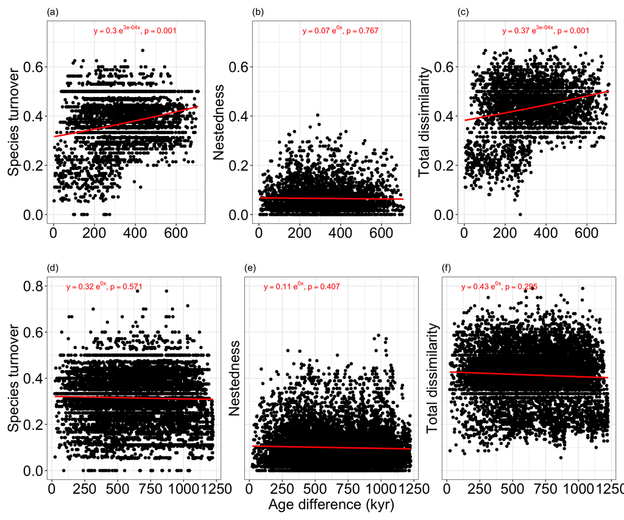

```r
p1/p2
```

Fig. X. Decomposition of pairwise Sørensen dissimilarities. (a) Species turnover between pre-MPT and MPT, (b) Nestedness between pre-MPT and MPT, (c) total dissimilarity between pre-MPT and MPT, (d) species turnover between MPT and post-MPT, (e) Nestedness between MPT and post-MPT, (f) total dissimilarity between MPT and post-MPT. The results indicate that the pairwise Sorensen dissimilarity between the Pre-MPT and MPT samples is dominated by species turnover. The species turnover and Sorensen dissimilarities significantly increase with the age difference. Similarly, the species turnover also dominates the pairwise Sorensen dissimilarity between the MPT and post-MPT samples; however, none of the turnover, nestedness, and total dissimilarities vary with the age difference between the MPT and post-MPT samples.

## 1.3 Pairwise dissimilarities between pre-MPT and post-MPT

```r
library(betapart)
library(vegan)

mpt <- which(sam$Period2=="MPT")

# Partioning Sorensen dissimilarities
be <- beta.pair(spp[-mpt,] %>% decostand("pa"))

bd <- list()
bd$beta.sim$lab <- c("(a)", "Species turnover")
bd$beta.sim$dis <- be$beta.sim
bd$beta.sne$lab <- c("(b)", "Nestedness")
bd$beta.sne$dis <- be$beta.sne
bd$beta.sor$lab <- c("(c)", "Total dissimilarity")
bd$beta.sor$dis <- be$beta.sor

pre <- which(sam[-mpt, "Period2"]=="Pre")
pos <- which(sam[-mpt, "Period2"]=="Post")
```

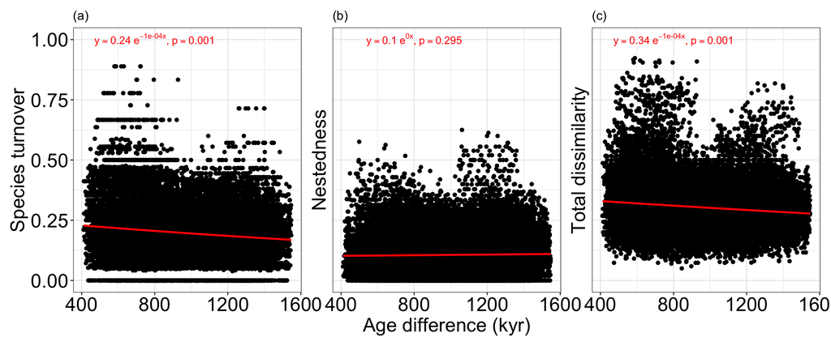

```r
lapply(bd, FUN=function(x){
  dis <- as.matrix(x$dis)
  dis[pre, pre] <- NA # Set dissimilarities among pre-MPT samples to NA
  dis[pos, pos] <- NA # Set dissimilarities among MPT samples to NA
  ydis <- as.dist(dis)

  dis <- as.matrix(dist(sam[-mpt, "Age_ka"]))
  xdis <- as.dist(dis)

  # Fit an exponential decay model
  f <- decay.model(ydis,  xdis, y.type = "dissimilarities", perm = 999)

  # Extract coefficients
  p <- round(f$p.value, 3)
  r2 <- round(f$pseudo.r.squared, 3)
  a <- round(f$first.parameter, 2) %>% as.vector
  b <- round(f$second.parameter, 4) %>% as.vector

  # Exponential equation
  eq <- bquote(y == .(a) ~ e^{.(b) * x}*"," ~ p==.(p))

  dat <- cbind(x = xdis  , y = ydis) %>% na.omit %>% as.data.frame
  ggplot(data = dat, aes(x=x, y=y))+
    geom_point()+
    annotate("text", x=800, y=1, label=as.expression(eq) %>% as.character(), parse=T, colour="red")+
    labs(x="Age difference (kyr)", y=x$lab[2], title=x$lab[1])+
    ylim(0, 1)+
    stat_smooth(method = "nls", formula = y ~ a * exp(b * x),
              method.args = list(start = list(a = a, b = b)),
              se = FALSE, color = "red")+
    theme_bw() %+replace% large
}) %>% wrap_plots(axes = "collect")
```

## 1.4 Pairwise dissimilarity among pre-MPT samples only

```r
# Any site pairs
pre <- which(sam$Period2=="Pre")
mpt <- which(sam$Period2=="MPT")
pos <- which(sam$Period2=="Post")

# Partioning Sorensen dissimilarities
be <- beta.pair(spp %>% decostand("pa"))

bd <- list()
bd$beta.sim$lab <- c(1, "Species turnover")
bd$beta.sim$dis <- be$beta.sim
bd$beta.sne$lab <- c(2, "Nestedness")
bd$beta.sne$dis <- be$beta.sne
bd$beta.sor$lab <- c(3, "Total dissimilarity")
bd$beta.sor$dis <- be$beta.sor
```

```r
p1 <- lapply(bd, FUN=function(x){
  dis <- as.matrix(x$dis)[pre, pre]
  ydis <- as.dist(dis)

  dis <- as.matrix(dist(sam$Age_ka))[pre, pre]
  xdis <- as.dist(dis)

  # Fit an exponential decay model
  f <- decay.model(ydis,  xdis, y.type = "dissimilarities", perm = 999)

  # Extract coefficients
  p <- round(f$p.value, 3)
  r2 <- round(f$pseudo.r.squared, 3)
  a <- round(f$first.parameter, 2) %>% as.vector
  b <- round(f$second.parameter, 4) %>% as.vector

  # Exponential equation
  eq <- bquote(y == .(a) ~ e^{.(b) * x}*"," ~ p==.(p))

  dat <- cbind(x = xdis  , y = ydis) %>% na.omit %>% as.data.frame
  dat$Period2 <- "Pre"
  ggplot(data = dat, aes(x=x, y=y))+
    geom_point()+
    annotate("text", x=150, y=0.6, label=as.expression(eq) %>% as.character(), parse=T, colour="red")+
    labs(x="", y=x$lab[2], title=paste("(", letters[1:3], ")", sep="")[as.numeric(x$lab[1])])+
    ylim(0, 0.6)+
    stat_smooth(method = "nls", formula = y ~ a * exp(b * x),
              method.args = list(start = list(a = a, b = b)),
              se = FALSE, color = "red")+
    facet_wrap(~Period2, scale = "free")+
    theme_bw() %+replace% large
}) %>% wrap_plots(axes = "collect")
```

Fig. X. Decomposition of pairwise Sørensen dissimilarities among the pre-MPT samples. (a) Species turnover, (b) Nestedness, (c) total dissimilarity. The results indicate that the pairwise Sorensen dissimilarity between the Pre-MPT samples is dominated by species turnover.

## 1.5 Pairwise dissimilarity among MPT samples only

```r
p2 <- lapply(bd, FUN=function(x){
  dis <- as.matrix(x$dis)[mpt, mpt]
  ydis <- as.dist(dis)

  dis <- as.matrix(dist(sam$Age_ka))[mpt, mpt]
  xdis <- as.dist(dis)

  # Fit an exponential decay model
  f <- decay.model(ydis,  xdis, y.type = "dissimilarities", perm = 999)

  # Extract coefficients
  p <- round(f$p.value, 3)
  r2 <- round(f$pseudo.r.squared, 3)
  a <- round(f$first.parameter, 2) %>% as.vector
  b <- round(f$second.parameter, 4) %>% as.vector

  # Exponential equation
  eq <- bquote(y == .(a) ~ e^{.(b) * x}*"," ~ p==.(p))

  dat <- cbind(x = xdis  , y = ydis) %>% na.omit %>% as.data.frame
  dat$Period2 <- "MPT"
  ggplot(data = dat, aes(x=x, y=y))+
    geom_point()+
    annotate("text", x=200, y=0.6, label=as.expression(eq) %>% as.character(), parse=T, colour="red")+
    labs(x="", y=x$lab[2], title=paste("(", letters[4:6], ")", sep="")[as.numeric(x$lab[1])])+
    ylim(0, 0.6)+
    stat_smooth(method = "nls", formula = y ~ a * exp(b * x),
              method.args = list(start = list(a = a, b = b)),
              se = FALSE, color = "red")+
    facet_wrap(~Period2, scale = "free")+
    theme_bw() %+replace% large
}) %>% wrap_plots(axes = "collect")
```

Fig. X. Decomposition of pairwise Sørensen dissimilarities among the MPT samples. (a) Species turnover, (b) Nestedness, (c) total dissimilarity. The results indicate that the pairwise Sorensen dissimilarity among the MPT samples is dominated by species turnover.

## 1.6 Pairwise dissimilarity among post-MPT samples only

```r
p3 <- lapply(bd, FUN=function(x){
  dis <- as.matrix(x$dis)[pos, pos]
  ydis <- as.dist(dis)

  dis <- as.matrix(dist(sam$Age_ka))[pos, pos]
  xdis <- as.dist(dis)

  # Fit an exponential decay model
  f <- decay.model(ydis,  xdis, y.type = "dissimilarities", perm = 999)

  # Extract coefficients
  p <- round(f$p.value, 3)
  r2 <- round(f$pseudo.r.squared, 3)
  a <- round(f$first.parameter, 2) %>% as.vector
  b <- round(f$second.parameter, 4) %>% as.vector

  # Exponential equation
  eq <- bquote(y == .(a) ~ e^{.(b) * x}*"," ~ p==.(p))

  dat <- cbind(x = xdis  , y = ydis) %>% na.omit %>% as.data.frame
  dat$Period2 <- "Post"
  ggplot(data = dat, aes(x=x, y=y))+
    geom_point()+
    annotate("text", x=400, y=0.95, label=as.expression(eq) %>% as.character(), parse=T, colour="red")+
    labs(x="Age difference (kyr)", y=x$lab[2], title=paste("(", letters[7:9], ")", sep="")[as.numeric(x$lab[1])])+
    ylim(0, 1)+
    stat_smooth(method = "nls", formula = y ~ a * exp(b * x),
              method.args = list(start = list(a = a, b = b)),
              se = FALSE, color = "red")+
    facet_wrap(~Period2, scale = "free")+
    theme_bw() %+replace% large
}) %>% wrap_plots(axes = "collect")
```

Fig. X. Decomposition of pairwise Sørensen dissimilarities among the Post-MPT samples. (a) Species turnover, (b) Nestedness, (c) total dissimilarity. The results indicate that the species turnover and nestedness contribute similarly to the pairwise Sorensen dissimilarity among the Post-MPT samples.

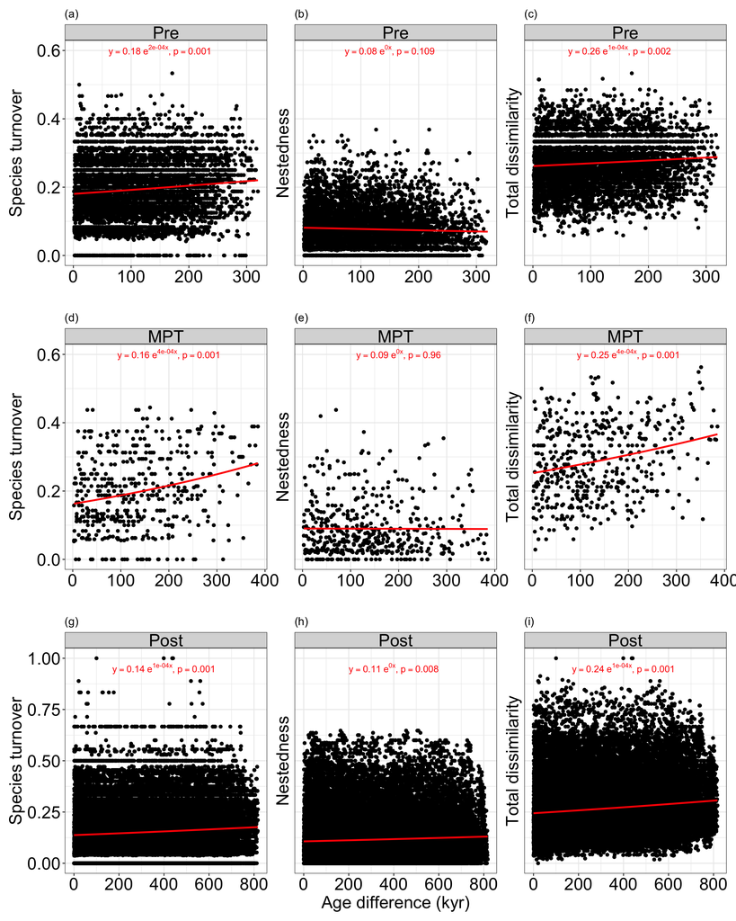

```r
p1/p2/p3
```

Fig. X. Decomposition of pairwise Sørensen dissimilarities among the Pre-MPT (a-c), MPT (d-f), and Post-MPT samples (g-i). Panels show Species turnover (a, d, g) , Nestedness (b, e, h) , and total dissimilarity (c, f, i). The results indicate that the species turnover and nestedness contribute similarly to the pairwise Sorensen dissimilarity among the Post-MPT samples.